# **1. Membuat Gelombang Sinus dan Cosinus**

Sinyal didefinisikan selama 2 periode. Bentuk umum sinyal sinusoidal adalah

$A \cdot \sin(2\pi f t + \phi)$ atau $A \cdot \cos(2\pi f t + \phi)$

di mana:

- $A$ adalah amplitudo,
- $f$ adalah frekuensi,
- $\phi$ adalah fase,
- Periode $T = \frac{1}{f}$.

Berikut ini adalah persamaan gelombang sinus dan cosinus yang digunakan:

Frequencies:

- $y_1$: Frequency $f_1 = 3$ Hz, so period $T_1 = \frac{1}{3}$ seconds.
- $y_2$: Frequency $f_2 = 4$ Hz, so period $T_2 = \frac{1}{4}$ seconds.
- $y_3$: Frequency $f_3 = 5$ Hz, so period $T_3 = \frac{1}{5}$ seconds.
- $y_4$: Frequency $f_4 = 6$ Hz, so period $T_4 = \frac{1}{6}$ seconds.

For 2 periods, the longest period is $T_1 = \frac{1}{3}$, so 2 periods = $\frac{2}{3}$ seconds. Number of points:

$$\text{Number of points} = \frac{\text{Duration}}{\Delta t} = \frac{\frac{2}{3}}{0.0001} = \frac{2}{3} \cdot 10^4 \approx 6667$$

Kode di bawah ini menggunakan NumPy untuk menghitung nilai sinyal berdasarkan array waktu.

```python
# Cell 1: Generate sine and cosine waves
import numpy as np

# Parameters
step_size = 0.0001  # Delta t
duration = 2/3      # 2 periods of the signal with the longest period (f=3 Hz)
t = np.arange(0, duration, step_size)  # Time array

# Generate the signals
y1 = 2 * np.sin(2 * np.pi * 3 * t + 0)          # 2 * sin(2π * 3 * t + 0)
y2 = 1 * np.cos(2 * np.pi * 4 * t + np.pi/4)    # 1 * cos(2π * 4 * t + π/4)
y3 = 1 * np.sin(2 * np.pi * 5 * t + np.pi/2)    # 1 * sin(2π * 5 * t + π/2)
y4 = 0.5 * np.cos(2 * np.pi * 6 * t + np.pi)    # 0.5 * cos(2π * 6 * t + π)

print("Time array shape:", t.shape)
print("Signal shapes:", y1.shape, y2.shape, y3.shape, y4.shape)
```

```
Time array shape: (6667,)
Signal shapes: (6667,) (6667,) (6667,) (6667,)
```

# **2. Perbandingan Subplot**

Tahap ini melibatkan pembuatan visualisasi dengan 4 subplot dalam grid 2x2 untuk membandingkan sinyal $ y1 $, $ y2 $, $ y3 $, dan $ y4 $ secara berdampingan. Setiap subplot menampilkan satu sinyal dengan label dan judul yang sesuai untuk memudahkan identifikasi. Matplotlib digunakan untuk membuat plot ini, dengan penyesuaian layout menggunakan `tight_layout()` agar tidak tumpang tindih.

[figure not shown]

```python
import matplotlib.pyplot as plt

# Create a 2x2 subplot grid
plt.figure(figsize=(10, 8))

# Enable LaTeX rendering for Matplotlib (optional but recommended)
plt.rc('text', usetex=True)  # Uncomment if you have LaTeX installed
plt.rc('font', family='serif')

# Subplot 1: y1 (Blue)
plt.subplot(2, 2, 1)
plt.plot(t, y1, color='b', label=r'$y_1 = 2 \sin(2\pi \cdot 3 \cdot t)$')
plt.title('Signal $y_1$')
plt.xlabel('Time (s)')
plt.ylabel('Amplitude')
plt.grid(True)
plt.legend(loc='lower right')
plt.ylim(-2.5, 2.5)

# Subplot 2: y2 (Green)
plt.subplot(2, 2, 2)
plt.plot(t, y2, color='g', label=r'$y_2 = \cos(2\pi \cdot 4 \cdot t + \frac{\pi}{4})$')
plt.title('Signal $y_2$')
plt.xlabel('Time (s)')
plt.ylabel('Amplitude')
plt.grid(True)
plt.legend(loc='lower right')
plt.ylim(-2.5, 2.5)

# Subplot 3: y3 (Red)
plt.subplot(2, 2, 3)
plt.plot(t, y3, color='r', label=r'$y_3 = -1 \cdot \sin(2\pi \cdot 5 \cdot t + \frac{\pi}{2})$')
plt.title('Signal $y_3$')
plt.xlabel('Time (s)')
plt.ylabel('Amplitude')
plt.grid(True)
plt.legend(loc='lower right')
plt.ylim(-2.5, 2.5)

# Subplot 4: y4 (Purple)
plt.subplot(2, 2, 4)
plt.plot(t, y4, color='m', label=r'$y_4 = 0.5 \cos(2\pi \cdot 6 \cdot t + \pi)$')
plt.title('Signal $y_4$')
plt.xlabel('Time (s)')
plt.ylabel('Amplitude')
plt.grid(True)
plt.legend(loc='lower right')
plt.ylim(-2.5, 2.5)

# Adjust layout to prevent overlap
plt.tight_layout()
plt.show()
```

# **3. Pertanyaan Analisis**

## **A. Berapa amplitudo dan frekuensi masing-masing sinyal?**

Jawaban

### **Menghitung Amplitudo dan Frekuensi untuk Setiap Sinyal**

#### **Sinyal $y_1 = 2 \cdot \sin(2\pi \cdot 3 \cdot t + 0)$**:

- **Amplitudo**:
  - Persamaannya adalah $y_1 = 2 \cdot \sin(2\pi \cdot 3 \cdot t + 0)$.
  - Koefisien fungsi sinus adalah 2.
  - Oleh karena itu, amplitudo $A_1 = 2$. Ini berarti $y_1$ berosilasi antara $-2$ dan $+2$.
- **Frekuensi**:
  - Argumen fungsi sinus adalah $2\pi \cdot 3 \cdot t + 0$.
  - Koefisien $t$ adalah $2\pi \cdot 3$.
  - Menggunakan rumus frekuensi: $$ 2\pi f_1 = 2\pi \cdot 3 \implies f_1 = \frac{2\pi \cdot 3}{2\pi} = 3 $$
- Jadi, frekuensi $f_1 = 3$ Hz, yang berarti $y_1$ menyelesaikan 3 siklus per detik.
- Atau, persamaan tersebut ditulis sebagai $2\pi \cdot 3 \cdot t$, di mana 3 secara langsung merupakan frekuensi: $f_1 = 3$ Hz.

#### **Sinyal $y_2 = 1 \cdot \cos(2\pi \cdot 4 \cdot t + \frac{\pi}{4})$**:

- **Amplitudo**:
  - Persamaannya adalah $y_2 = 1 \cdot \cos(2\pi \cdot 4 \cdot t + \frac{\pi}{4})$.
  - Koefisien fungsi kosinus adalah 1.
  - Oleh karena itu, amplitudo $A_2 = 1$. Ini berarti $y_2$ berosilasi antara $-1$ dan $+1$.
- **Frekuensi**:
  - Argumen fungsi kosinus adalah $2\pi \cdot 4 \cdot t + \frac{\pi}{4}$.
  - Koefisien $t$ adalah $2\pi \cdot 4$.
  - Menggunakan rumus: $$ 2\pi f_2 = 2\pi \cdot 4 \implies f_2 = \frac{2\pi \cdot 4}{2\pi} = 4 $$
- Jadi, frekuensi $f_2 = 4$ Hz, yang berarti $y_2$ menyelesaikan 4 siklus per detik.
- Langsung dari persamaan, $f_2 = 4$ Hz.

#### **Sinyal $y_3 = 1 \cdot \sin(2\pi \cdot 5 \cdot t + \frac{\pi}{2})$**:

- **Amplitudo**:
  - Persamaannya adalah $y_3 = 1 \cdot \sin(2\pi \cdot 5 \cdot t + \frac{\pi}{2})$.
  - Koefisien fungsi sinus adalah 1. Oleh karena itu, amplitudo $A_3 = 1$. Ini berarti $y_3$ berosilasi antara $-1$ dan $+1$.

**Frekuensi**:

## **B. Bagaimana pergeseran fase mempengaruhi posisi gelombang?**

Jawaban

Pergeseran fase ($ \phi $) dalam gelombang sinusoidal $ A \cdot \sin(2 \pi f t + \phi) $ atau $ A \cdot \cos(2 \pi f t + \phi) $ menggeser posisi gelombang secara horizontal. Pergeseran fase positif (misalnya $ \pi/2 $) menggeser gelombang ke kiri (maju), sedangkan negatif menggeser ke kanan (mundur). Sebagai contoh, jika fase $ y1 $ diubah dari 0 menjadi $ \pi/2 $, gelombang akan bergeser sebesar seperempat siklus ke kiri.

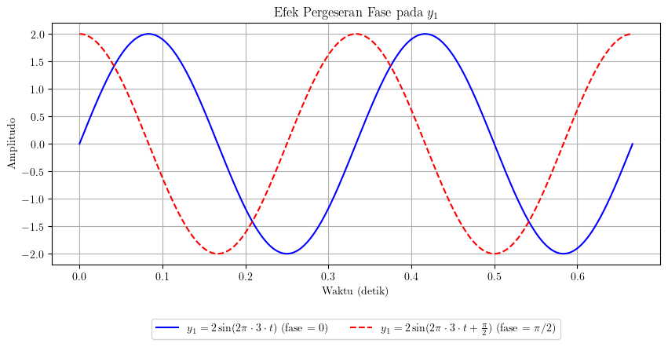

```
Pergeseran waktu untuk fase phi = pi/2: 0.0833 detik
Periode y1: T = 1/3 ≈ 0.333 detik
Seperempat siklus: T/4 = (1/3)/4 = 1/12 ≈ 0.0833 detik, sesuai dengan pergeseran waktu.
```

```python
import numpy as np
import matplotlib.pyplot as plt

# Parameter
step_size = 0.0001  # Delta t (langkah waktu)
duration = 2/3      # Durasi: 2 periode y1 (f=3 Hz, T=1/3 s)
t = np.arange(0, duration, step_size)  # Array waktu

# Sinyal asli y1 dengan fase = 0
y1_original = 2 * np.sin(2 * np.pi * 3 * t + 0)

# Sinyal y1 dengan pergeseran fase = pi/2
y1_shifted = 2 * np.sin(2 * np.pi * 3 * t + np.pi/2)

# Konfigurasi LaTeX untuk Matplotlib (opsional, uncomment jika LaTeX terinstal)
plt.rc('text', usetex=True)
plt.rc('font', family='serif')

# Plotting
plt.figure(figsize=(10, 4))
plt.plot(t, y1_original, label=r'$y_1 = 2 \sin(2\pi \cdot 3 \cdot t)$ (fase = 0)', color='blue')
plt.plot(t, y1_shifted, label=r'$y_1 = 2 \sin(2\pi \cdot 3 \cdot t + \frac{\pi}{2})$ (fase = $\pi/2$)', color='red', linestyle='--')
plt.title(r'Efek Pergeseran Fase pada $y_1$')
plt.xlabel('Waktu (detik)')
plt.ylabel('Amplitudo')
plt.grid(True)
plt.legend(loc='upper center', bbox_to_anchor=(0.5, -0.2), ncol=2)
plt.show()


# Hitung dan tampilkan pergeseran waktu
f = 3  # Frekuensi y1
phi = np.pi/2
time_shift = phi / (2 * np.pi * f)
print(f"Pergeseran waktu untuk fase phi = pi/2: {time_shift:.4f} detik")
print(f"Periode y1: T = 1/3 ≈ 0.333 detik")
print(f"Seperempat siklus: T/4 = (1/3)/4 = 1/12 ≈ 0.0833 detik, sesuai dengan pergeseran waktu.")
```

## **C. Bandingkan sinyal-sinyal dengan amplitudo yang berbeda dan diskusikan bagaimana amplitudo mempengaruhi tampilan gelombang**

Jawaban

Amplitudo menentukan skala vertikal gelombang, yaitu nilai maksimum dan minimum yang dicapai gelombang. Amplitudo yang lebih besar berarti gelombang yang lebih tinggi, sedangkan amplitudo yang lebih kecil berarti gelombang yang lebih pendek.

- Untuk $y_1$ dengan $A_1 = 2$, gelombang berosilasi antara $-2$ dan $+2$, menjadikannya yang tertinggi di antara sinyal-sinyal.
- Untuk $y_2$ dan $y_3$ dengan $A_2 = A_3 = 1$, gelombang berosilasi antara $-1$ dan $+1$, setengah dari tinggi $y_1$.
- Untuk $y_4$ dengan $A_4 = 0,5$, gelombang berosilasi antara $-0,5$ dan $+0,5$, yang terpendek di antara sinyal-sinyal.

Dalam petak petak 2x2 (dari tugas sebelumnya di atas), hal ini tampak jelas secara visual bahwa $y_1$ memiliki puncak terbesar, $y_2$ dan $y_3$ memiliki puncak sedang, dan $y_4$ memiliki puncak terkecil. Amplitudo secara langsung mengubah skala gelombang secara vertikal, memengaruhi intensitas atau kekuatan yang dirasakan, tetapi tidak mengubah frekuensi atau fasenya.

[figure not shown]

## **D. Bandingkan sinyal-sinyal dengan pergeseran fase yang berbeda dan diskusikan bagaimana pergeseran fase mempengaruhi tampilan gelombang**

Jawaban

- Pergeseran fase yang berbeda ($ 0, \pi/4, \pi/2, \pi $) mengubah titik awal gelombang. Misalnya, $ y2 $ dimulai pada nilai positif karena $ \pi/4 $, sementara $ y4 $ dimulai pada puncak negatif karena $ \pi $, yang memengaruhi perataan dan interferensi saat digabungkan.

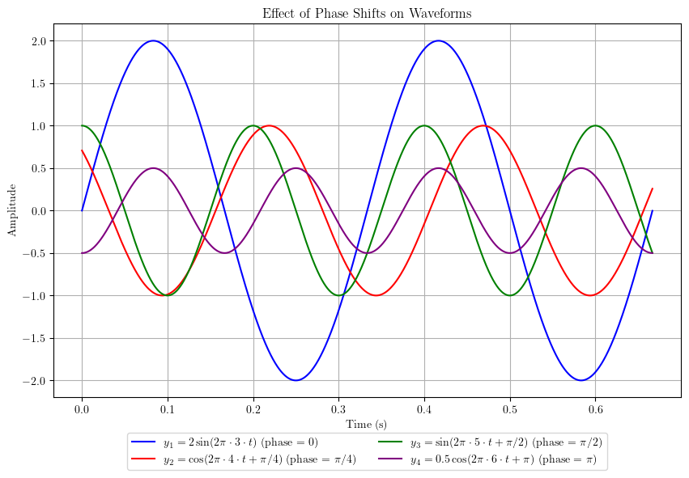

$\displaystyle y_1 = 2 \sin(2\pi \cdot 3 \cdot t)$

$\displaystyle y_2 = \cos(2\pi \cdot 4 \cdot t + \frac{\pi}{4})$

$\displaystyle y_3 = \sin(2\pi \cdot 5 \cdot t + \frac{\pi}{2})$

$\displaystyle y_4 = 0.5 \cos(2\pi \cdot 6 \cdot t + \pi)$

$\displaystyle \text{Observation: Each waveform shifts left based on its phase. } y_1 \text{ (phase 0) starts at 0, } y_2 \text{ (phase } \pi/4 \text{) shifts slightly, } y_3 \text{ (phase } \pi/2 \text{) starts at peak, } y_4 \text{ (phase } \pi \text{) is flipped and shifted.}$

```python
# Cell: Visualize Phase Shifts with LaTeX Rendered Equations
import numpy as np
import matplotlib.pyplot as plt
from IPython.display import display, Math

# Enable LaTeX rendering in Matplotlib (using built-in renderer)
plt.rc('text', usetex=True)  # Set to True if you have a LaTeX installation

# Parameters
step_size = 0.0001  # Delta t
duration = 2/3      # 2 periods of y1 (f=3 Hz, T=1/3 s)
t = np.arange(0, duration, step_size)  # Time array

# Generate the signals
y1 = 2 * np.sin(2 * np.pi * 3 * t + 0)              # Phase = 0
y2 = 1 * np.cos(2 * np.pi * 4 * t + np.pi/4)        # Phase = π/4
y3 = 1 * np.sin(2 * np.pi * 5 * t + np.pi/2)        # Phase = π/2
y4 = 0.5 * np.cos(2 * np.pi * 6 * t + np.pi)        # Phase = π

# Plotting with raw strings for LaTeX labels
plt.figure(figsize=(10, 6))
plt.plot(t, y1, label=r'$y_1 = 2 \sin(2\pi \cdot 3 \cdot t)$ (phase = 0)', color='blue')
plt.plot(t, y2, label=r'$y_2 = \cos(2\pi \cdot 4 \cdot t + \pi/4)$ (phase = $\pi/4$)', color='red')
plt.plot(t, y3, label=r'$y_3 = \sin(2\pi \cdot 5 \cdot t + \pi/2)$ (phase = $\pi/2$)', color='green')
plt.plot(t, y4, label=r'$y_4 = 0.5 \cos(2\pi \cdot 6 \cdot t + \pi)$ (phase = $\pi$)', color='purple')

plt.title('Effect of Phase Shifts on Waveforms')
plt.xlabel('Time (s)')
plt.ylabel('Amplitude')
plt.grid(True)
plt.legend(loc='upper center', bbox_to_anchor=(0.5, -0.08), ncol=2)
plt.show()

# Render LaTeX equations for the signals
display(Math(r'y_1 = 2 \sin(2\pi \cdot 3 \cdot t)'))
display(Math(r'y_2 = \cos(2\pi \cdot 4 \cdot t + \frac{\pi}{4})'))
display(Math(r'y_3 = \sin(2\pi \cdot 5 \cdot t + \frac{\pi}{2})'))
display(Math(r'y_4 = 0.5 \cos(2\pi \cdot 6 \cdot t + \pi)'))

# Render observation with LaTeX
display(Math(r'\text{Observation: Each waveform shifts left based on its phase. } y_1 \text{ (phase 0) starts at 0, } y_2 \text{ (phase } \pi/4 \text{) shifts slightly, } y_3 \text{ (phase } \pi/2 \text{) starts at peak, } y_4 \text{ (phase } \pi \text{) is flipped and shifted.}'))
```

# 4. Tugas Lanjutan

A. Buat sinyal baru $y5$ yang merupakan kombinasi dari $y1$ dan $y2$ yaitu $y5=y1+y2$

```python
import numpy as np
import matplotlib.pyplot as plt
plt.rc('text', usetex=True)  # Set to True if you have a LaTeX installation

# Parameters
step_size = 0.0001  # Delta t
duration = 2/3      # 2 periods of y1 (f=3 Hz, T=1/3 s)
t = np.arange(0, duration, step_size)  # Time array

# Generate the original signals
y1 = 2 * np.sin(2 * np.pi * 3 * t + 0)              # Phase = 0
y2 = 1 * np.cos(2 * np.pi * 4 * t + np.pi/4)        # Phase = π/4

# Create y5 as the sum of y1 and y2
y5 = y1 + y2
```

B. Plot $y5$ dan diskusikan bagaimana kombinasi dua gelombang sinus/cosinus mempengaruhi bentuk gelombang yang dihasilkan.

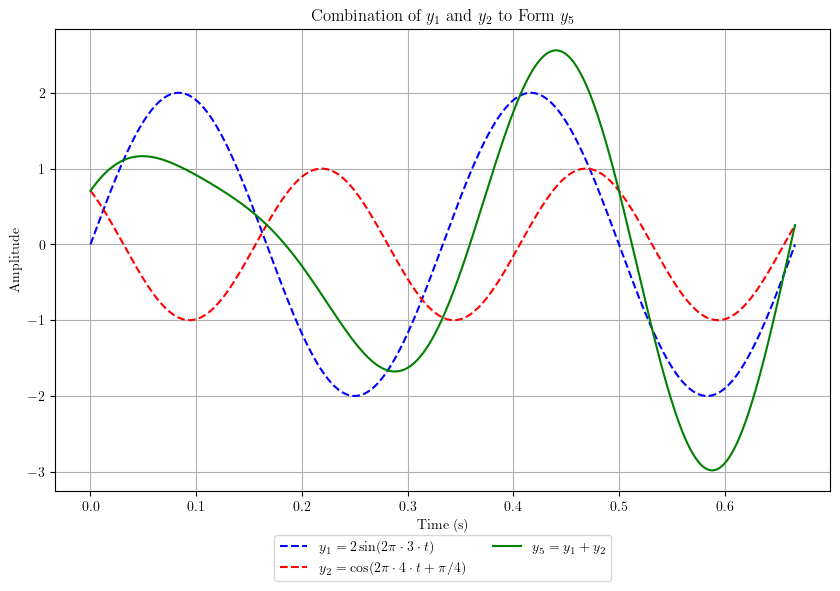

```python
from IPython.display import display, Math
from IPython.display import Markdown

# Plotting
plt.figure(figsize=(10, 6))
plt.plot(t, y1, label=r'$y_1 = 2 \sin(2\pi \cdot 3 \cdot t)$', color='blue', linestyle='--')
plt.plot(t, y2, label=r'$y_2 = \cos(2\pi \cdot 4 \cdot t + \pi/4)$', color='red', linestyle='--')
plt.plot(t, y5, label=r'$y_5 = y_1 + y_2$', color='green')
plt.title('Combination of $y_1$ and $y_2$ to Form $y_5$')
plt.xlabel('Time (s)')
plt.ylabel('Amplitude')
plt.grid(True)
plt.legend(loc='upper center', bbox_to_anchor=(0.5, -0.08), ncol=2)
plt.show()
```

**Pengaruh Kombinasi Gelombang Sinus/Cosinus**

Kombinasi $ y_1 $ dan $ y_2 $ menghasilkan $ y_5 $, yaitu penjumlahan dua gelombang sinusoidal dengan frekuensi, amplitudo, dan fase yang berbeda:

- $ y_1 $ memiliki frekuensi $ 3 $ Hz, amplitudo $ 2 $, dan fase $0 $.
- $ y_2 $ memiliki frekuensi $ 4 $ Hz, amplitudo $ 1 $, dan fase $\frac{\pi}{4}$.

### **Pengaruh Kombinasi**

- **Interferensi**:  
  Gelombang $ y_1 $ dan $ y_2 $ saling bertemu, kadang menambah tinggi (interferensi konstruktif) dan kadang menurunkan (interferensi destruktif), sehingga $ y_5 $ menunjukkan pola osilasi yang rumit.
- **Frekuensi Berbeda**:  
  Perbedaan frekuensi $ 3 $ Hz dan $ 4 $ Hz menciptakan efek *beat* (irama), dengan frekuensi beat sekitar:

  $$ f_{\text{beat}} = |3 - 4| = 1 \text{ Hz} $$

  Hal ini menyebabkan amplitudo $ y_5 $ berubah-ubah secara periodik.
- **Amplitudo**:  
  Amplitudo maksimum $ y_5 $ dapat mencapai:

  $$ A_{\max} = 2 + 1 = 3 $$

  saat terjadi interferensi konstruktif, dan lebih kecil saat interferensi destruktif.
- **Fase**:  
  Fase $\frac{\pi}{4}$ pada $ y_2 $ menyebabkan pergeseran relatif terhadap $ y_1 $, yang memengaruhi titik-titik pertemuan gelombang.
- **Bentuk Gelombang**:  
  $ y_5 $ tidak lagi murni sinusoidal, melainkan kombinasi yang menunjukkan variasi amplitudo dan frekuensi yang lebih kompleks.

### **Kesimpulan**

Kombinasi dua gelombang sinus/cosinus menghasilkan gelombang baru yang bentuknya dipengaruhi oleh frekuensi, amplitudo, dan fase masing-masing. Pola interferensi dan efek *beat* membuat $ y_5 $ memiliki karakteristik yang lebih beragam dibandingkan gelombang aslinya.

LAMPIRAN

Beberapa referensi dan link percakapan dengan LLM dalam membantu mengerjakan tugas ini:

- [Grok By XAi](https://grok.com/share/bGVnYWN5_f8d34150-63d7-4268-8fe1-f88cf39c5f3b)
- [Generating Sine Wave in Python](https://youtu.be/2g9GSS6g4IM?feature=shared)
- [IPython Display Docs](https://ipython.readthedocs.io/en/8.26.0/api/generated/IPython.display.html)
- [Matplotlib Docs](https://matplotlib.org/stable/api/index.html)